# DESCRIPTION

Reduce the time a Mercedes-Benz spends on the test bench.

## Problem Statement Scenario:

Since the first automobile, the Benz Patent Motor Car in 1886, Mercedes-Benz has stood for important automotive innovations. These include the passenger safety cell with a crumple zone, the airbag, and intelligent assistance systems. Mercedes-Benz applies for nearly 2000 patents per year, making the brand the European leader among premium carmakers. Mercedes-Benz is the leader in the premium car industry. With a huge selection of features and options, customers can choose the customized Mercedes-Benz of their dreams.

To ensure the safety and reliability of every unique car configuration before they hit the road, the company’s engineers have developed a robust testing system. As one of the world’s biggest manufacturers of premium cars, safety and efficiency are paramount on Mercedes-Benz’s production lines. However, optimizing the speed of their testing system for many possible feature combinations is complex and time-consuming without a powerful algorithmic approach.

You are required to reduce the time that cars spend on the test bench. Others will work with a dataset representing different permutations of features in a Mercedes-Benz car to predict the time it takes to pass testing. Optimal algorithms will contribute to faster testing, resulting in lower carbon dioxide emissions without reducing Mercedes-Benz’s standards.

## Following actions should be performed:

If for any column(s), the variance is equal to zero, then you need to remove those variable(s). Check for null and unique values for test and train sets. Apply label encoder. Perform dimensionality reduction. Predict your test_df values using XGBoost

```python
import pandas as pd
import numpy as np
import matplotlib.pyplot as plt
%matplotlib inline
import seaborn as sns
```

```python
import io
%cd "D:\Mercedes\Mercedes"
```

```
D:\Mercedes\Mercedes
```

```python
train_df=pd.read_csv("train.csv")
test_df=pd.read_csv("test.csv")
pd.set_option("display.max_columns",None)
pd.set_option("display.max_rows",None)
```

```python
train_df.head()
```

|  | ID | y | X0 | X1 | X2 | X3 | X4 | X5 | X6 | X8 | X10 | X11 | X12 | X13 | X14 | X15 | X16 | X17 | X18 | X19 | X20 | X21 | X22 | X23 | X24 | X26 | X27 | X28 | X29 | … |
| --- | --- | --- | --- | --- | --- | --- | --- | --- | --- | --- | --- | --- | --- | --- | --- | --- | --- | --- | --- | --- | --- | --- | --- | --- | --- | --- | --- | --- | --- | --- |
| 0 | 0 | 130.81 | k | v | at | a | d | u | j | o | 0 | 0 | 0 | 1 | 0 | 0 | 0 | 0 | 1 | 0 | 0 | 1 | 0 | 0 | 0 | 0 | 0 | 0 | 0 | … |
| 1 | 6 | 88.53 | k | t | av | e | d | y | l | o | 0 | 0 | 0 | 0 | 0 | 0 | 0 | 0 | 1 | 0 | 0 | 0 | 0 | 0 | 0 | 0 | 1 | 0 | 0 | … |
| 2 | 7 | 76.26 | az | w | n | c | d | x | j | x | 0 | 0 | 0 | 0 | 0 | 0 | 0 | 1 | 0 | 0 | 0 | 0 | 0 | 0 | 0 | 0 | 1 | 1 | 1 | … |
| 3 | 9 | 80.62 | az | t | n | f | d | x | l | e | 0 | 0 | 0 | 0 | 0 | 0 | 0 | 0 | 0 | 0 | 0 | 0 | 0 | 0 | 0 | 0 | 1 | 1 | 1 | … |
| 4 | 13 | 78.02 | az | v | n | f | d | h | d | n | 0 | 0 | 0 | 0 | 0 | 0 | 0 | 0 | 0 | 0 | 0 | 0 | 0 | 0 | 0 | 0 | 1 | 1 | 1 | … |

```python
train_df.shape
```

```
(4209, 378)
```

```python
test_df.head()
```

|  | ID | X0 | X1 | X2 | X3 | X4 | X5 | X6 | X8 | X10 | X11 | X12 | X13 | X14 | X15 | X16 | X17 | X18 | X19 | X20 | X21 | X22 | X23 | X24 | X26 | X27 | X28 | X29 | X30 | … |
| --- | --- | --- | --- | --- | --- | --- | --- | --- | --- | --- | --- | --- | --- | --- | --- | --- | --- | --- | --- | --- | --- | --- | --- | --- | --- | --- | --- | --- | --- | --- |
| 0 | 1 | az | v | n | f | d | t | a | w | 0 | 0 | 0 | 0 | 0 | 0 | 0 | 0 | 0 | 0 | 0 | 0 | 0 | 0 | 0 | 0 | 1 | 1 | 1 | 0 | … |
| 1 | 2 | t | b | ai | a | d | b | g | y | 0 | 0 | 0 | 0 | 0 | 0 | 0 | 0 | 0 | 1 | 0 | 0 | 0 | 0 | 0 | 0 | 1 | 0 | 0 | 0 | … |
| 2 | 3 | az | v | as | f | d | a | j | j | 0 | 0 | 0 | 0 | 1 | 0 | 0 | 0 | 0 | 0 | 0 | 0 | 0 | 0 | 0 | 0 | 1 | 0 | 1 | 0 | … |
| 3 | 4 | az | l | n | f | d | z | l | n | 0 | 0 | 0 | 0 | 0 | 0 | 0 | 0 | 0 | 0 | 0 | 0 | 0 | 0 | 0 | 0 | 1 | 1 | 1 | 0 | … |
| 4 | 5 | w | s | as | c | d | y | i | m | 0 | 0 | 0 | 0 | 1 | 0 | 0 | 0 | 0 | 0 | 0 | 0 | 0 | 0 | 0 | 0 | 1 | 0 | 0 | 0 | … |

```python
##If for any column(s), the variance is equal to zero, then you need to remove those variable(s)
```

```python
L=[]
for i in train_df.columns[10:]:
    if train_df[i].var() ==0:
        L.append(i)
print(L)
#These are the columns with variance is 0
```

```
['X11', 'X93', 'X107', 'X233', 'X235', 'X268', 'X289', 'X290', 'X293', 'X297', 'X330', 'X347']
```

```python
train_df=train_df.drop(L,axis=1)
```

```python
train_df.head()
```

|  | ID | y | X0 | X1 | X2 | X3 | X4 | X5 | X6 | X8 | X10 | X12 | X13 | X14 | X15 | X16 | X17 | X18 | X19 | X20 | X21 | X22 | X23 | X24 | X26 | X27 | X28 | X29 | X30 | … |
| --- | --- | --- | --- | --- | --- | --- | --- | --- | --- | --- | --- | --- | --- | --- | --- | --- | --- | --- | --- | --- | --- | --- | --- | --- | --- | --- | --- | --- | --- | --- |
| 0 | 0 | 130.81 | k | v | at | a | d | u | j | o | 0 | 0 | 1 | 0 | 0 | 0 | 0 | 1 | 0 | 0 | 1 | 0 | 0 | 0 | 0 | 0 | 0 | 0 | 0 | … |
| 1 | 6 | 88.53 | k | t | av | e | d | y | l | o | 0 | 0 | 0 | 0 | 0 | 0 | 0 | 1 | 0 | 0 | 0 | 0 | 0 | 0 | 0 | 1 | 0 | 0 | 0 | … |
| 2 | 7 | 76.26 | az | w | n | c | d | x | j | x | 0 | 0 | 0 | 0 | 0 | 0 | 1 | 0 | 0 | 0 | 0 | 0 | 0 | 0 | 0 | 1 | 1 | 1 | 0 | … |
| 3 | 9 | 80.62 | az | t | n | f | d | x | l | e | 0 | 0 | 0 | 0 | 0 | 0 | 0 | 0 | 0 | 0 | 0 | 0 | 0 | 0 | 0 | 1 | 1 | 1 | 0 | … |
| 4 | 13 | 78.02 | az | v | n | f | d | h | d | n | 0 | 0 | 0 | 0 | 0 | 0 | 0 | 0 | 0 | 0 | 0 | 0 | 0 | 0 | 0 | 1 | 1 | 1 | 0 | … |

```python
train_df.shape
```

```
(4209, 366)
```

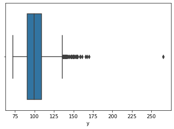

```python
sns.boxplot(train_df["y"])
#there is one value which is extremely out of trend so we have to remove this outliers
```

```python
train_df.loc[train_df["y"]==train_df["y"].max()]
```

|  | ID | y | X0 | X1 | X2 | X3 | X4 | X5 | X6 | X8 | X10 | X12 | X13 | X14 | X15 | X16 | X17 | X18 | X19 | X20 | X21 | X22 | X23 | X24 | X26 | X27 | X28 | X29 | X30 | … |
| --- | --- | --- | --- | --- | --- | --- | --- | --- | --- | --- | --- | --- | --- | --- | --- | --- | --- | --- | --- | --- | --- | --- | --- | --- | --- | --- | --- | --- | --- | --- |
| 883 | 1770 | 265.32 | y | r | ai | f | d | ag | l | t | 0 | 0 | 0 | 0 | 0 | 0 | 0 | 0 | 1 | 0 | 0 | 0 | 0 | 0 | 0 | 1 | 0 | 0 | 0 | … |

```python
train_df=train_df.drop(883)
```

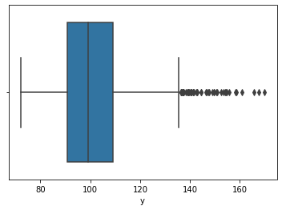

```python
sns.boxplot(train_df["y"])
```

```python
train_df.shape
```

```
(4208, 366)
```

```python
train_df.isnull().sum().sort_values(ascending=False)
#No Null value in our data
```

```
ID      0
X262    0
X260    0
X259    0
X258    0
X257    0
X256    0
X255    0
X254    0
X253    0
X252    0
X251    0
X250    0
X249    0
X248    0
X247    0
X246    0
X245    0
X244    0
X243    0
X242    0
X261    0
X263    0
X240    0
X264    0
X284    0
X283    0
X282    0
X281    0
X280    0
X279    0
X278    0
X277    0
X276    0
X275    0
X274    0
X273    0
X272    0
X271    0
X270    0
```

[output cut: 312 more lines]

```
X135    0
X134    0
X133    0
X131    0
X122    0
X130    0
X129    0
X128    0
X127    0
X126    0
X125    0
X124    0
X123    0
X385    0
dtype: int64
```

```python
test_df.isnull().sum().sort_values(ascending=False)
#no Null value in test data as well
```

```
ID      0
X255    0
X264    0
X263    0
X262    0
X261    0
X260    0
X259    0
X258    0
X257    0
X256    0
X254    0
X266    0
X253    0
X252    0
X251    0
X250    0
X249    0
X248    0
X247    0
X246    0
X245    0
X265    0
X267    0
X196    0
X279    0
X288    0
X287    0
X286    0
X285    0
X284    0
X283    0
X282    0
X281    0
X280    0
X278    0
X268    0
X277    0
X276    0
X275    0
```

[output cut: 323 more lines]

```
X137    0
X136    0
X135    0
X134    0
X133    0
X132    0
X131    0
X130    0
X129    0
X128    0
X127    0
X126    0
X125    0
X385    0
dtype: int64
```

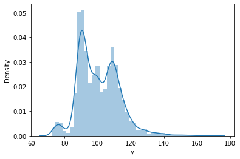

```python
sns.distplot(train_df["y"])
```

```python
train_df.head()
```

|  | ID | y | X0 | X1 | X2 | X3 | X4 | X5 | X6 | X8 | X10 | X12 | X13 | X14 | X15 | X16 | X17 | X18 | X19 | X20 | X21 | X22 | X23 | X24 | X26 | X27 | X28 | X29 | X30 | … |
| --- | --- | --- | --- | --- | --- | --- | --- | --- | --- | --- | --- | --- | --- | --- | --- | --- | --- | --- | --- | --- | --- | --- | --- | --- | --- | --- | --- | --- | --- | --- |
| 0 | 0 | 130.81 | k | v | at | a | d | u | j | o | 0 | 0 | 1 | 0 | 0 | 0 | 0 | 1 | 0 | 0 | 1 | 0 | 0 | 0 | 0 | 0 | 0 | 0 | 0 | … |
| 1 | 6 | 88.53 | k | t | av | e | d | y | l | o | 0 | 0 | 0 | 0 | 0 | 0 | 0 | 1 | 0 | 0 | 0 | 0 | 0 | 0 | 0 | 1 | 0 | 0 | 0 | … |
| 2 | 7 | 76.26 | az | w | n | c | d | x | j | x | 0 | 0 | 0 | 0 | 0 | 0 | 1 | 0 | 0 | 0 | 0 | 0 | 0 | 0 | 0 | 1 | 1 | 1 | 0 | … |
| 3 | 9 | 80.62 | az | t | n | f | d | x | l | e | 0 | 0 | 0 | 0 | 0 | 0 | 0 | 0 | 0 | 0 | 0 | 0 | 0 | 0 | 0 | 1 | 1 | 1 | 0 | … |
| 4 | 13 | 78.02 | az | v | n | f | d | h | d | n | 0 | 0 | 0 | 0 | 0 | 0 | 0 | 0 | 0 | 0 | 0 | 0 | 0 | 0 | 0 | 1 | 1 | 1 | 0 | … |

```python
train_df.drop(["ID"],axis=1,inplace=True)
```

```python
train_df.head()
```

|  | y | X0 | X1 | X2 | X3 | X4 | X5 | X6 | X8 | X10 | X12 | X13 | X14 | X15 | X16 | X17 | X18 | X19 | X20 | X21 | X22 | X23 | X24 | X26 | X27 | X28 | X29 | X30 | X31 | … |
| --- | --- | --- | --- | --- | --- | --- | --- | --- | --- | --- | --- | --- | --- | --- | --- | --- | --- | --- | --- | --- | --- | --- | --- | --- | --- | --- | --- | --- | --- | --- |
| 0 | 130.81 | k | v | at | a | d | u | j | o | 0 | 0 | 1 | 0 | 0 | 0 | 0 | 1 | 0 | 0 | 1 | 0 | 0 | 0 | 0 | 0 | 0 | 0 | 0 | 1 | … |
| 1 | 88.53 | k | t | av | e | d | y | l | o | 0 | 0 | 0 | 0 | 0 | 0 | 0 | 1 | 0 | 0 | 0 | 0 | 0 | 0 | 0 | 1 | 0 | 0 | 0 | 1 | … |
| 2 | 76.26 | az | w | n | c | d | x | j | x | 0 | 0 | 0 | 0 | 0 | 0 | 1 | 0 | 0 | 0 | 0 | 0 | 0 | 0 | 0 | 1 | 1 | 1 | 0 | 1 | … |
| 3 | 80.62 | az | t | n | f | d | x | l | e | 0 | 0 | 0 | 0 | 0 | 0 | 0 | 0 | 0 | 0 | 0 | 0 | 0 | 0 | 0 | 1 | 1 | 1 | 0 | 1 | … |
| 4 | 78.02 | az | v | n | f | d | h | d | n | 0 | 0 | 0 | 0 | 0 | 0 | 0 | 0 | 0 | 0 | 0 | 0 | 0 | 0 | 0 | 1 | 1 | 1 | 0 | 1 | … |

```python
object_col=train_df.select_dtypes("O")
```

```python
object_col
```

|  | X0 | X1 | X2 | X3 | X4 | X5 | X6 | X8 |
| --- | --- | --- | --- | --- | --- | --- | --- | --- |
| 0 | k | v | at | a | d | u | j | o |
| 1 | k | t | av | e | d | y | l | o |
| 2 | az | w | n | c | d | x | j | x |
| 3 | az | t | n | f | d | x | l | e |
| 4 | az | v | n | f | d | h | d | n |
| 5 | t | b | e | c | d | g | h | s |
| 6 | al | r | e | f | d | f | h | s |
| 7 | o | l | as | f | d | f | j | a |
| 8 | w | s | as | e | d | f | i | h |
| 9 | j | b | aq | c | d | f | a | e |
| 10 | h | r | r | f | d | f | h | p |
| 11 | al | r | e | f | d | f | h | o |
| 12 | s | b | ai | c | d | f | g | m |
| 13 | al | r | e | f | d | j | h | o |
| 14 | o | s | as | e | d | j | g | m |
| 15 | n | l | ak | f | d | j | d | k |
| 16 | al | r | e | f | d | j | h | o |
| 17 | ay | aa | as | c | d | j | c | d |
| 18 | f | c | m | c | d | j | d | e |
| 19 | n | a | ak | f | d | j | i | s |
| 20 | f | s | m | c | d | j | j | i |
| 21 | t | aa | as | d | d | j | j | s |
| 22 | x | r | a | b | d | j | j | o |
| 23 | x | b | m | c | d | j | j | n |
| 24 | y | r | ak | d | d | j | d | s |
| 25 | o | s | m | c | d | j | i | v |
| 26 | aj | l | as | f | d | j | g | j |
| 27 | t | aa | as | c | d | j | d | b |
| 28 | f | s | as | c | d | j | c | q |
| 29 | x | b | m | c | d | j | j | n |

[output cut: 4178 more lines]

```python
counts_x0=object_col["X0"].value_counts()
counts_x1=object_col["X1"].value_counts()
counts_x2=object_col["X2"].value_counts()
counts_x3=object_col["X3"].value_counts()
counts_x4=object_col["X4"].value_counts()
counts_x5=object_col["X5"].value_counts()
counts_x6=object_col["X6"].value_counts()
counts_x8=object_col["X8"].value_counts()
```

```python
threshold_x0=40
threshold_x1=40
threshold_x2=40
threshold_x3=40
threshold_x4=40
threshold_x5=90
threshold_x6=90
threshold_x8=100
```

```python
repl_x0 = counts_x0[counts_x0 <= threshold_x0].index
repl_x1 = counts_x1[counts_x1 <= threshold_x1].index
repl_x2 = counts_x2[counts_x2 <= threshold_x2].index
repl_x3 = counts_x3[counts_x3 <= threshold_x3].index
repl_x4 = counts_x4[counts_x4 <= threshold_x4].index
repl_x5 = counts_x5[counts_x5 <= threshold_x5].index
repl_x6 = counts_x6[counts_x6 <= threshold_x6].index
repl_x8 = counts_x8[counts_x8 <= threshold_x8].index
```

```python
df_X0=pd.get_dummies(object_col['X0'].replace(repl_x0, 'Other_X0'),drop_first=True,prefix="x0_")
df_X1=pd.get_dummies(object_col['X1'].replace(repl_x1, 'Other_X1'),drop_first=True,prefix="x1_")
df_X2=pd.get_dummies(object_col['X2'].replace(repl_x2, 'Other_X2'),drop_first=True,prefix="x2_")
df_X3=pd.get_dummies(object_col['X3'].replace(repl_x3, 'Other_X3'),drop_first=True,prefix="x3_")
df_X4=pd.get_dummies(object_col['X4'].replace(repl_x4, 'Other_X4'),drop_first=True,prefix="x4_")
df_X5=pd.get_dummies(object_col['X5'].replace(repl_x5, 'Other_X5'),drop_first=True,prefix="x5_")
df_X6=pd.get_dummies(object_col['X6'].replace(repl_x6, 'Other_X6'),drop_first=True,prefix="x6_")
df_X8=pd.get_dummies(object_col['X8'].replace(repl_x8, 'Other_X8'),drop_first=True,prefix="x8_")
```

```python
object_col1=pd.concat([df_X0,df_X1,df_X2,df_X3,df_X4,df_X5,df_X6,df_X8],axis=1)
```

```python
train_df=pd.concat([train_df,object_col1],axis=1)
```

```python
train_df.head()
```

|  | y | X0 | X1 | X2 | X3 | X4 | X5 | X6 | X8 | X10 | X12 | X13 | X14 | X15 | X16 | X17 | X18 | X19 | X20 | X21 | X22 | X23 | X24 | X26 | X27 | X28 | X29 | X30 | X31 | … |
| --- | --- | --- | --- | --- | --- | --- | --- | --- | --- | --- | --- | --- | --- | --- | --- | --- | --- | --- | --- | --- | --- | --- | --- | --- | --- | --- | --- | --- | --- | --- |
| 0 | 130.81 | k | v | at | a | d | u | j | o | 0 | 0 | 1 | 0 | 0 | 0 | 0 | 1 | 0 | 0 | 1 | 0 | 0 | 0 | 0 | 0 | 0 | 0 | 0 | 1 | … |
| 1 | 88.53 | k | t | av | e | d | y | l | o | 0 | 0 | 0 | 0 | 0 | 0 | 0 | 1 | 0 | 0 | 0 | 0 | 0 | 0 | 0 | 1 | 0 | 0 | 0 | 1 | … |
| 2 | 76.26 | az | w | n | c | d | x | j | x | 0 | 0 | 0 | 0 | 0 | 0 | 1 | 0 | 0 | 0 | 0 | 0 | 0 | 0 | 0 | 1 | 1 | 1 | 0 | 1 | … |
| 3 | 80.62 | az | t | n | f | d | x | l | e | 0 | 0 | 0 | 0 | 0 | 0 | 0 | 0 | 0 | 0 | 0 | 0 | 0 | 0 | 0 | 1 | 1 | 1 | 0 | 1 | … |
| 4 | 78.02 | az | v | n | f | d | h | d | n | 0 | 0 | 0 | 0 | 0 | 0 | 0 | 0 | 0 | 0 | 0 | 0 | 0 | 0 | 0 | 1 | 1 | 1 | 0 | 1 | … |

```python
train_df.shape
```

```
(4208, 467)
```

```python
train_df=train_df.drop(object_col.columns,axis=1)
```

```python
train_df.head()
```

|  | y | X10 | X12 | X13 | X14 | X15 | X16 | X17 | X18 | X19 | X20 | X21 | X22 | X23 | X24 | X26 | X27 | X28 | X29 | X30 | X31 | X32 | X33 | X34 | X35 | X36 | X37 | X38 | X39 | … |
| --- | --- | --- | --- | --- | --- | --- | --- | --- | --- | --- | --- | --- | --- | --- | --- | --- | --- | --- | --- | --- | --- | --- | --- | --- | --- | --- | --- | --- | --- | --- |
| 0 | 130.81 | 0 | 0 | 1 | 0 | 0 | 0 | 0 | 1 | 0 | 0 | 1 | 0 | 0 | 0 | 0 | 0 | 0 | 0 | 0 | 1 | 0 | 0 | 0 | 1 | 0 | 1 | 0 | 0 | … |
| 1 | 88.53 | 0 | 0 | 0 | 0 | 0 | 0 | 0 | 1 | 0 | 0 | 0 | 0 | 0 | 0 | 0 | 1 | 0 | 0 | 0 | 1 | 0 | 0 | 0 | 1 | 0 | 1 | 0 | 0 | … |
| 2 | 76.26 | 0 | 0 | 0 | 0 | 0 | 0 | 1 | 0 | 0 | 0 | 0 | 0 | 0 | 0 | 0 | 1 | 1 | 1 | 0 | 1 | 0 | 0 | 0 | 1 | 0 | 1 | 0 | 0 | … |
| 3 | 80.62 | 0 | 0 | 0 | 0 | 0 | 0 | 0 | 0 | 0 | 0 | 0 | 0 | 0 | 0 | 0 | 1 | 1 | 1 | 0 | 1 | 0 | 0 | 0 | 1 | 0 | 1 | 0 | 0 | … |
| 4 | 78.02 | 0 | 0 | 0 | 0 | 0 | 0 | 0 | 0 | 0 | 0 | 0 | 0 | 0 | 0 | 0 | 1 | 1 | 1 | 0 | 1 | 0 | 0 | 0 | 1 | 0 | 1 | 0 | 0 | … |

```python
train_df.shape
```

```
(4208, 459)
```

```python
test_df.head()
```

|  | ID | X0 | X1 | X2 | X3 | X4 | X5 | X6 | X8 | X10 | X11 | X12 | X13 | X14 | X15 | X16 | X17 | X18 | X19 | X20 | X21 | X22 | X23 | X24 | X26 | X27 | X28 | X29 | X30 | … |
| --- | --- | --- | --- | --- | --- | --- | --- | --- | --- | --- | --- | --- | --- | --- | --- | --- | --- | --- | --- | --- | --- | --- | --- | --- | --- | --- | --- | --- | --- | --- |
| 0 | 1 | az | v | n | f | d | t | a | w | 0 | 0 | 0 | 0 | 0 | 0 | 0 | 0 | 0 | 0 | 0 | 0 | 0 | 0 | 0 | 0 | 1 | 1 | 1 | 0 | … |
| 1 | 2 | t | b | ai | a | d | b | g | y | 0 | 0 | 0 | 0 | 0 | 0 | 0 | 0 | 0 | 1 | 0 | 0 | 0 | 0 | 0 | 0 | 1 | 0 | 0 | 0 | … |
| 2 | 3 | az | v | as | f | d | a | j | j | 0 | 0 | 0 | 0 | 1 | 0 | 0 | 0 | 0 | 0 | 0 | 0 | 0 | 0 | 0 | 0 | 1 | 0 | 1 | 0 | … |
| 3 | 4 | az | l | n | f | d | z | l | n | 0 | 0 | 0 | 0 | 0 | 0 | 0 | 0 | 0 | 0 | 0 | 0 | 0 | 0 | 0 | 0 | 1 | 1 | 1 | 0 | … |
| 4 | 5 | w | s | as | c | d | y | i | m | 0 | 0 | 0 | 0 | 1 | 0 | 0 | 0 | 0 | 0 | 0 | 0 | 0 | 0 | 0 | 0 | 1 | 0 | 0 | 0 | … |

```python
Objcol_test=test_df.select_dtypes("O")
```

```python
Objcol_test
```

|  | X0 | X1 | X2 | X3 | X4 | X5 | X6 | X8 |
| --- | --- | --- | --- | --- | --- | --- | --- | --- |
| 0 | az | v | n | f | d | t | a | w |
| 1 | t | b | ai | a | d | b | g | y |
| 2 | az | v | as | f | d | a | j | j |
| 3 | az | l | n | f | d | z | l | n |
| 4 | w | s | as | c | d | y | i | m |
| 5 | y | aa | ai | e | d | x | g | s |
| 6 | x | b | ae | d | d | x | d | y |
| 7 | f | s | ae | c | d | h | d | a |
| 8 | ap | l | s | c | d | h | j | n |
| 9 | o | v | as | f | d | g | f | v |
| 10 | ap | l | s | c | d | g | d | n |
| 11 | ay | b | b | a | d | g | l | r |
| 12 | al | r | e | f | d | g | h | o |
| 13 | o | v | ae | g | d | g | g | j |
| 14 | h | a | ak | f | d | g | l | t |
| 15 | al | r | e | f | d | g | h | s |
| 16 | ap | l | s | c | d | g | d | h |
| 17 | al | r | e | f | d | f | h | o |
| 18 | z | i | ai | a | d | f | l | c |
| 19 | y | r | as | f | d | f | d | c |
| 20 | al | r | e | f | d | f | h | o |
| 21 | al | r | e | f | d | f | h | o |
| 22 | z | v | ai | e | d | f | j | m |
| 23 | al | r | e | f | d | j | h | o |
| 24 | y | b | ai | c | d | j | g | k |
| 25 | ap | l | s | c | d | j | j | w |
| 26 | ay | aa | m | c | d | j | g | t |
| 27 | ay | a | as | d | d | j | l | h |
| 28 | f | s | m | c | d | j | g | a |
| 29 | az | p | as | f | d | j | g | a |

[output cut: 4179 more lines]

```python
counts_test_x0=Objcol_test["X0"].value_counts()
counts_test_x1=Objcol_test["X1"].value_counts()
counts_test_x2=Objcol_test["X2"].value_counts()
counts_test_x3=Objcol_test["X3"].value_counts()
counts_test_x4=Objcol_test["X4"].value_counts()
counts_test_x5=Objcol_test["X5"].value_counts()
counts_test_x6=Objcol_test["X6"].value_counts()
counts_test_x8=Objcol_test["X8"].value_counts()
```

```python
repl_test_x0 = counts_test_x0[counts_test_x0 <= threshold_x0].index
repl_test_x1 = counts_test_x1[counts_test_x1 <= threshold_x1].index
repl_test_x2 = counts_test_x2[counts_test_x2 <= threshold_x2].index
repl_test_x3 = counts_test_x3[counts_test_x3 <= threshold_x3].index
repl_test_x4 = counts_test_x4[counts_test_x4 <= threshold_x4].index
repl_test_x5 = counts_test_x5[counts_test_x5 <= threshold_x5].index
repl_test_x6 = counts_test_x6[counts_test_x6 <= threshold_x6].index
repl_test_x8 = counts_test_x8[counts_test_x8 <= threshold_x8].index
```

```python
df_test_X0=pd.get_dummies(Objcol_test['X0'].replace(repl_test_x0, 'Other_X0'),drop_first=True,prefix="x0_")
df_test_X1=pd.get_dummies(Objcol_test['X1'].replace(repl_test_x1, 'Other_X1'),drop_first=True,prefix="x1_")
df_test_X2=pd.get_dummies(Objcol_test['X2'].replace(repl_test_x2, 'Other_X2'),drop_first=True,prefix="x2_")
df_test_X3=pd.get_dummies(Objcol_test['X3'].replace(repl_test_x3, 'Other_X3'),drop_first=True,prefix="x3_")
df_test_X4=pd.get_dummies(Objcol_test['X4'].replace(repl_test_x4, 'Other_X4'),drop_first=True,prefix="x4_")
df_test_X5=pd.get_dummies(Objcol_test['X5'].replace(repl_test_x5, 'Other_X5'),drop_first=True,prefix="x5_")
df_test_X6=pd.get_dummies(Objcol_test['X6'].replace(repl_test_x6, 'Other_X6'),drop_first=True,prefix="x6_")
df_test_X8=pd.get_dummies(Objcol_test['X8'].replace(repl_test_x8, 'Other_X8'),drop_first=True,prefix="x8_")
```

```python
object_col2=pd.concat([df_test_X0,df_test_X1,df_test_X2,df_test_X3,df_test_X4,df_test_X5,df_test_X6,df_test_X8],axis=1)
```

```python
object_col2.head()
```

|  | x0__aj | x0__ak | x0__al | x0__ap | x0__ay | x0__az | x0__d | x0__e | x0__f | x0__h | x0__j | x0__n | x0__o | x0__s | x0__t | x0__w | x0__x | x0__y | x0__z | x1__a | x1__aa | x1__b | x1__c | x1__i | x1__l | x1__o | x1__r | x1__s | x1__v | … |
| --- | --- | --- | --- | --- | --- | --- | --- | --- | --- | --- | --- | --- | --- | --- | --- | --- | --- | --- | --- | --- | --- | --- | --- | --- | --- | --- | --- | --- | --- | --- |
| 0 | 0 | 0 | 0 | 0 | 0 | 1 | 0 | 0 | 0 | 0 | 0 | 0 | 0 | 0 | 0 | 0 | 0 | 0 | 0 | 0 | 0 | 0 | 0 | 0 | 0 | 0 | 0 | 0 | 1 | … |
| 1 | 0 | 0 | 0 | 0 | 0 | 0 | 0 | 0 | 0 | 0 | 0 | 0 | 0 | 0 | 1 | 0 | 0 | 0 | 0 | 0 | 0 | 1 | 0 | 0 | 0 | 0 | 0 | 0 | 0 | … |
| 2 | 0 | 0 | 0 | 0 | 0 | 1 | 0 | 0 | 0 | 0 | 0 | 0 | 0 | 0 | 0 | 0 | 0 | 0 | 0 | 0 | 0 | 0 | 0 | 0 | 0 | 0 | 0 | 0 | 1 | … |
| 3 | 0 | 0 | 0 | 0 | 0 | 1 | 0 | 0 | 0 | 0 | 0 | 0 | 0 | 0 | 0 | 0 | 0 | 0 | 0 | 0 | 0 | 0 | 0 | 0 | 1 | 0 | 0 | 0 | 0 | … |
| 4 | 0 | 0 | 0 | 0 | 0 | 0 | 0 | 0 | 0 | 0 | 0 | 0 | 0 | 0 | 0 | 1 | 0 | 0 | 0 | 0 | 0 | 0 | 0 | 0 | 0 | 0 | 0 | 1 | 0 | … |

```python
test_df=pd.concat([test_df,object_col2],axis=1)
```

```python
test_df.head()
```

|  | ID | X0 | X1 | X2 | X3 | X4 | X5 | X6 | X8 | X10 | X11 | X12 | X13 | X14 | X15 | X16 | X17 | X18 | X19 | X20 | X21 | X22 | X23 | X24 | X26 | X27 | X28 | X29 | X30 | … |
| --- | --- | --- | --- | --- | --- | --- | --- | --- | --- | --- | --- | --- | --- | --- | --- | --- | --- | --- | --- | --- | --- | --- | --- | --- | --- | --- | --- | --- | --- | --- |
| 0 | 1 | az | v | n | f | d | t | a | w | 0 | 0 | 0 | 0 | 0 | 0 | 0 | 0 | 0 | 0 | 0 | 0 | 0 | 0 | 0 | 0 | 1 | 1 | 1 | 0 | … |
| 1 | 2 | t | b | ai | a | d | b | g | y | 0 | 0 | 0 | 0 | 0 | 0 | 0 | 0 | 0 | 1 | 0 | 0 | 0 | 0 | 0 | 0 | 1 | 0 | 0 | 0 | … |
| 2 | 3 | az | v | as | f | d | a | j | j | 0 | 0 | 0 | 0 | 1 | 0 | 0 | 0 | 0 | 0 | 0 | 0 | 0 | 0 | 0 | 0 | 1 | 0 | 1 | 0 | … |
| 3 | 4 | az | l | n | f | d | z | l | n | 0 | 0 | 0 | 0 | 0 | 0 | 0 | 0 | 0 | 0 | 0 | 0 | 0 | 0 | 0 | 0 | 1 | 1 | 1 | 0 | … |
| 4 | 5 | w | s | as | c | d | y | i | m | 0 | 0 | 0 | 0 | 1 | 0 | 0 | 0 | 0 | 0 | 0 | 0 | 0 | 0 | 0 | 0 | 1 | 0 | 0 | 0 | … |

```python
test_df=test_df.drop(Objcol_test.columns,axis=1)
```

```python
test_df=test_df.drop(["ID"],axis=1)
```

```python
train_df.head()
```

|  | y | X10 | X12 | X13 | X14 | X15 | X16 | X17 | X18 | X19 | X20 | X21 | X22 | X23 | X24 | X26 | X27 | X28 | X29 | X30 | X31 | X32 | X33 | X34 | X35 | X36 | X37 | X38 | X39 | … |
| --- | --- | --- | --- | --- | --- | --- | --- | --- | --- | --- | --- | --- | --- | --- | --- | --- | --- | --- | --- | --- | --- | --- | --- | --- | --- | --- | --- | --- | --- | --- |
| 0 | 130.81 | 0 | 0 | 1 | 0 | 0 | 0 | 0 | 1 | 0 | 0 | 1 | 0 | 0 | 0 | 0 | 0 | 0 | 0 | 0 | 1 | 0 | 0 | 0 | 1 | 0 | 1 | 0 | 0 | … |
| 1 | 88.53 | 0 | 0 | 0 | 0 | 0 | 0 | 0 | 1 | 0 | 0 | 0 | 0 | 0 | 0 | 0 | 1 | 0 | 0 | 0 | 1 | 0 | 0 | 0 | 1 | 0 | 1 | 0 | 0 | … |
| 2 | 76.26 | 0 | 0 | 0 | 0 | 0 | 0 | 1 | 0 | 0 | 0 | 0 | 0 | 0 | 0 | 0 | 1 | 1 | 1 | 0 | 1 | 0 | 0 | 0 | 1 | 0 | 1 | 0 | 0 | … |
| 3 | 80.62 | 0 | 0 | 0 | 0 | 0 | 0 | 0 | 0 | 0 | 0 | 0 | 0 | 0 | 0 | 0 | 1 | 1 | 1 | 0 | 1 | 0 | 0 | 0 | 1 | 0 | 1 | 0 | 0 | … |
| 4 | 78.02 | 0 | 0 | 0 | 0 | 0 | 0 | 0 | 0 | 0 | 0 | 0 | 0 | 0 | 0 | 0 | 1 | 1 | 1 | 0 | 1 | 0 | 0 | 0 | 1 | 0 | 1 | 0 | 0 | … |

```python
test_df.head()
```

|  | X10 | X11 | X12 | X13 | X14 | X15 | X16 | X17 | X18 | X19 | X20 | X21 | X22 | X23 | X24 | X26 | X27 | X28 | X29 | X30 | X31 | X32 | X33 | X34 | X35 | X36 | X37 | X38 | X39 | … |
| --- | --- | --- | --- | --- | --- | --- | --- | --- | --- | --- | --- | --- | --- | --- | --- | --- | --- | --- | --- | --- | --- | --- | --- | --- | --- | --- | --- | --- | --- | --- |
| 0 | 0 | 0 | 0 | 0 | 0 | 0 | 0 | 0 | 0 | 0 | 0 | 0 | 0 | 0 | 0 | 0 | 1 | 1 | 1 | 0 | 1 | 0 | 0 | 0 | 1 | 0 | 1 | 0 | 0 | … |
| 1 | 0 | 0 | 0 | 0 | 0 | 0 | 0 | 0 | 0 | 1 | 0 | 0 | 0 | 0 | 0 | 0 | 1 | 0 | 0 | 0 | 1 | 0 | 0 | 0 | 1 | 0 | 1 | 0 | 0 | … |
| 2 | 0 | 0 | 0 | 0 | 1 | 0 | 0 | 0 | 0 | 0 | 0 | 0 | 0 | 0 | 0 | 0 | 1 | 0 | 1 | 0 | 1 | 0 | 0 | 0 | 1 | 0 | 1 | 0 | 0 | … |
| 3 | 0 | 0 | 0 | 0 | 0 | 0 | 0 | 0 | 0 | 0 | 0 | 0 | 0 | 0 | 0 | 0 | 1 | 1 | 1 | 0 | 1 | 0 | 0 | 0 | 1 | 0 | 1 | 0 | 0 | … |
| 4 | 0 | 0 | 0 | 0 | 1 | 0 | 0 | 0 | 0 | 0 | 0 | 0 | 0 | 0 | 0 | 0 | 1 | 0 | 0 | 0 | 0 | 0 | 0 | 0 | 0 | 0 | 0 | 0 | 0 | … |

```python
train_df.shape
```

```
(4208, 459)
```

```python
test_df.shape
```

```
(4209, 470)
```

```python
Y=train_df["y"]
```

```python
X=train_df.iloc[:,1:]
```

```python
X.head()
```

|  | X10 | X12 | X13 | X14 | X15 | X16 | X17 | X18 | X19 | X20 | X21 | X22 | X23 | X24 | X26 | X27 | X28 | X29 | X30 | X31 | X32 | X33 | X34 | X35 | X36 | X37 | X38 | X39 | X40 | … |
| --- | --- | --- | --- | --- | --- | --- | --- | --- | --- | --- | --- | --- | --- | --- | --- | --- | --- | --- | --- | --- | --- | --- | --- | --- | --- | --- | --- | --- | --- | --- |
| 0 | 0 | 0 | 1 | 0 | 0 | 0 | 0 | 1 | 0 | 0 | 1 | 0 | 0 | 0 | 0 | 0 | 0 | 0 | 0 | 1 | 0 | 0 | 0 | 1 | 0 | 1 | 0 | 0 | 0 | … |
| 1 | 0 | 0 | 0 | 0 | 0 | 0 | 0 | 1 | 0 | 0 | 0 | 0 | 0 | 0 | 0 | 1 | 0 | 0 | 0 | 1 | 0 | 0 | 0 | 1 | 0 | 1 | 0 | 0 | 0 | … |
| 2 | 0 | 0 | 0 | 0 | 0 | 0 | 1 | 0 | 0 | 0 | 0 | 0 | 0 | 0 | 0 | 1 | 1 | 1 | 0 | 1 | 0 | 0 | 0 | 1 | 0 | 1 | 0 | 0 | 0 | … |
| 3 | 0 | 0 | 0 | 0 | 0 | 0 | 0 | 0 | 0 | 0 | 0 | 0 | 0 | 0 | 0 | 1 | 1 | 1 | 0 | 1 | 0 | 0 | 0 | 1 | 0 | 1 | 0 | 0 | 0 | … |
| 4 | 0 | 0 | 0 | 0 | 0 | 0 | 0 | 0 | 0 | 0 | 0 | 0 | 0 | 0 | 0 | 1 | 1 | 1 | 0 | 1 | 0 | 0 | 0 | 1 | 0 | 1 | 0 | 0 | 0 | … |

```python
X.shape
```

```
(4208, 458)
```

```python
#train test split
```

```python
from sklearn.model_selection import train_test_split
```

```python
x_train,x_test,y_train,y_test=train_test_split(X,Y,test_size=0.2,random_state=42)
```

```python
x_train.head()
```

|  | X10 | X12 | X13 | X14 | X15 | X16 | X17 | X18 | X19 | X20 | X21 | X22 | X23 | X24 | X26 | X27 | X28 | X29 | X30 | X31 | X32 | X33 | X34 | X35 | X36 | X37 | X38 | X39 | X40 | … |
| --- | --- | --- | --- | --- | --- | --- | --- | --- | --- | --- | --- | --- | --- | --- | --- | --- | --- | --- | --- | --- | --- | --- | --- | --- | --- | --- | --- | --- | --- | --- |
| 3830 | 0 | 0 | 0 | 0 | 0 | 0 | 0 | 0 | 0 | 1 | 0 | 0 | 0 | 0 | 0 | 1 | 0 | 0 | 0 | 0 | 0 | 0 | 0 | 0 | 0 | 0 | 1 | 0 | 0 | … |
| 152 | 0 | 0 | 0 | 0 | 0 | 0 | 0 | 0 | 0 | 0 | 0 | 0 | 0 | 0 | 0 | 0 | 0 | 0 | 0 | 1 | 0 | 0 | 0 | 1 | 0 | 1 | 0 | 0 | 0 | … |
| 1557 | 0 | 0 | 0 | 1 | 0 | 0 | 0 | 0 | 0 | 0 | 0 | 0 | 0 | 0 | 0 | 0 | 0 | 0 | 0 | 0 | 0 | 0 | 0 | 0 | 0 | 0 | 0 | 0 | 0 | … |
| 2358 | 0 | 1 | 0 | 0 | 0 | 0 | 0 | 0 | 0 | 0 | 0 | 0 | 0 | 0 | 0 | 1 | 0 | 0 | 0 | 0 | 0 | 0 | 0 | 0 | 0 | 0 | 0 | 0 | 0 | … |
| 1316 | 0 | 0 | 0 | 0 | 0 | 0 | 0 | 0 | 0 | 0 | 0 | 0 | 0 | 0 | 0 | 1 | 0 | 0 | 0 | 0 | 0 | 0 | 0 | 0 | 0 | 0 | 0 | 0 | 0 | … |

```python
x_test.head()
```

|  | X10 | X12 | X13 | X14 | X15 | X16 | X17 | X18 | X19 | X20 | X21 | X22 | X23 | X24 | X26 | X27 | X28 | X29 | X30 | X31 | X32 | X33 | X34 | X35 | X36 | X37 | X38 | X39 | X40 | … |
| --- | --- | --- | --- | --- | --- | --- | --- | --- | --- | --- | --- | --- | --- | --- | --- | --- | --- | --- | --- | --- | --- | --- | --- | --- | --- | --- | --- | --- | --- | --- |
| 1722 | 0 | 0 | 0 | 0 | 0 | 0 | 0 | 0 | 0 | 0 | 0 | 0 | 0 | 0 | 0 | 1 | 1 | 1 | 0 | 0 | 0 | 0 | 0 | 0 | 0 | 0 | 0 | 0 | 0 | … |
| 3550 | 0 | 0 | 0 | 0 | 0 | 0 | 0 | 0 | 0 | 1 | 0 | 0 | 0 | 0 | 0 | 0 | 0 | 0 | 0 | 0 | 0 | 0 | 0 | 0 | 0 | 0 | 0 | 0 | 0 | … |
| 2556 | 0 | 0 | 0 | 1 | 0 | 0 | 0 | 0 | 0 | 0 | 0 | 0 | 0 | 0 | 0 | 1 | 0 | 0 | 0 | 0 | 0 | 0 | 0 | 0 | 0 | 0 | 0 | 0 | 0 | … |
| 4021 | 0 | 0 | 0 | 0 | 0 | 0 | 0 | 0 | 0 | 1 | 0 | 0 | 0 | 0 | 0 | 0 | 0 | 0 | 0 | 0 | 0 | 0 | 0 | 0 | 0 | 0 | 0 | 0 | 0 | … |
| 3954 | 0 | 0 | 0 | 1 | 0 | 0 | 0 | 0 | 0 | 0 | 0 | 0 | 0 | 0 | 0 | 1 | 0 | 0 | 0 | 0 | 0 | 0 | 0 | 0 | 0 | 0 | 1 | 0 | 0 | … |

```python
y_train.head()
```

```
3830     89.46
152     108.84
1557    111.15
2358    122.65
1316     94.39
Name: y, dtype: float64
```

```python
y_test.head()
```

```
1722     77.62
3550     93.17
2556    109.02
4021     92.48
3954    113.67
Name: y, dtype: float64
```